# LSTAT2340 - Analyse de données transcriptomique : Affymetrix Gene Expression Microarray

Jerome Ambroise - UCL - IREC - CTMA

Februar 22, 2021,10:59

Dans le document, ci-dessous, nous allons analyser des données microarray générées avec une plateforme Affymetrix.

Les données proviennent de l’étude “MicroArray Quality Control (MAQC) project” dont un des papier vous est fourni. Dans ce document, nous analysons 5 échantillons A (A1, A2, A3, A4 et A5) et 5 échantillons B (B1, B2, B3, B4 et B5) et l’objectif est d’identifier les gènes qui sont modulés.

# 1 Chargement des packages et importation des données.

Nous commençons par charger le package Limma. Limma est un package bioconductor qui dispose d’un “user guide” très complet.

Le package ‘gcrma’ sera utilisé pour le prétraitement des données.

Le package ‘hgu133plus2.db’ sera utilisé pour annoter les sondes (ou “probes”).

```r
library(limma)
library(gcrma)
library(hgu133plus2.db)
```

Nous importons les données qui sont situées dans le répertoire 1-data/AFFX Il s’agit de 10 fichiers ‘.CEL’.

```r
rm(list=ls())
files <- list.files('1-data/AFFX/',full.names = T)
rawfiles <- ReadAffy(filenames=files)
rawfiles
```

```
## AffyBatch object
## size of arrays=1164x1164 features (21 kb)
## cdf=HG-U133_Plus_2 (54675 affyids)
## number of samples=10
## number of genes=54675
## annotation=hgu133plus2
## notes=
```

# 2 Pré-traitement des données.

Les données de microarray sont généralement pré-traitées en 3 étapes:

1: la correction du background

2: la normalisation

3: la transformation (généralement log2)

Avec les données de affymetrix, ces trois étapes sont généralement réalisée avec une seule fonction. GCRMA est une méthode standard pour réaliser ces trois étapes.

```r
expressionset <- gcrma(rawfiles)
```

```
## Adjusting for optical effect..........Done.
## Computing affinities.Done.
## Adjusting for non-specific binding..........Done.
## Normalizing
## Calculating Expression
```

```r
print(expressionset)
```

```
## ExpressionSet (storageMode: lockedEnvironment)
## assayData: 54675 features, 10 samples
##   element names: exprs
## protocolData
##   sampleNames: AFX_1_A1.CEL AFX_1_A2.CEL ... AFX_1_B5.CEL (10 total)
##   varLabels: ScanDate
##   varMetadata: labelDescription
## phenoData
##   sampleNames: AFX_1_A1.CEL AFX_1_A2.CEL ... AFX_1_B5.CEL (10 total)
##   varLabels: sample
##   varMetadata: labelDescription
## featureData: none
## experimentData: use 'experimentData(object)'
## Annotation: hgu133plus2
```

L’expressionset contient de nombreux “slots” dont la matrice d’expression. Il est intéressant de noter que pour le moment le ‘slot’ featureData est vide. Il s’agit du slot dans lequel doit être stocké la significaiton de chacune des sondes. Il est possible d’extraire cette matrice d’expression avec la fonction ‘exprs’.

## 2.1 assaydata = matrice d’expression

```r
assaydata <- assayData(expressionset)
expressionmatrix <- assaydata$exprs
dim(expressionmatrix)
```

```
## [1] 54675    10
```

```r
expressionmatrix[1:10,1:10]
```

```
##           AFX_1_A1.CEL AFX_1_A2.CEL AFX_1_A3.CEL AFX_1_A4.CEL AFX_1_A5.CEL
## 1007_s_at     8.154262     8.258640     8.330232     8.163093     8.108384
## 1053_at       8.718056     8.815388     8.739162     8.799744     8.840262
## 117_at        3.865689     3.937957     3.713142     3.716922     3.775492
## 121_at        4.972485     4.882711     5.054442     5.395737     4.863437
## 1255_g_at     2.245328     2.245328     2.245328     2.245328     2.245328
## 1294_at       5.300109     5.505185     5.243323     5.181908     5.307483
## 1316_at       3.311599     3.323757     3.408077     3.399933     3.322752
## 1320_at       2.305060     2.311773     2.342399     2.305060     2.305060
## 1405_i_at     3.978024     3.814771     3.253105     3.623642     4.058988
## 1431_at       2.959024     2.984661     2.751877     2.928043     2.984483
##           AFX_1_B1.CEL AFX_1_B2.CEL AFX_1_B3.CEL AFX_1_B4.CEL AFX_1_B5.CEL
## 1007_s_at     9.286791     9.339173     9.308381     9.383711     9.287204
## 1053_at       6.098138     6.272793     5.865782     6.015811     6.082908
## 117_at        4.439382     4.292097     4.010092     4.066746     4.148739
## 121_at        4.740067     4.856211     4.799693     4.782419     4.849314
## 1255_g_at     2.263026     2.245328     2.248209     2.245328     2.245328
## 1294_at       3.578577     3.928282     3.928282     4.011878     3.640915
## 1316_at       4.447311     3.746126     4.315038     3.927083     4.065318
## 1320_at       2.306404     2.305060     2.305060     2.305060     2.391690
## 1405_i_at     2.295090     2.295090     2.295090     2.413973     2.385536
## 1431_at       5.347107     5.451553     5.153894     5.379400     5.491991
```

## 2.2 protocolData = données du protocole

```r
protocol <- protocolData(expressionset)
pData(protocol)
```

```
##                       ScanDate
## AFX_1_A1.CEL 09/07/05 13:38:28
## AFX_1_A2.CEL 09/07/05 12:01:05
## AFX_1_A3.CEL 09/07/05 12:14:02
## AFX_1_A4.CEL 09/07/05 12:34:41
## AFX_1_A5.CEL 09/07/05 13:50:54
## AFX_1_B1.CEL 09/07/05 13:25:38
## AFX_1_B2.CEL 09/07/05 13:12:47
## AFX_1_B3.CEL 09/07/05 13:00:04
## AFX_1_B4.CEL 09/07/05 12:47:21
## AFX_1_B5.CEL 09/07/05 14:03:23
```

## 2.3 phenoData = données phénotypiques

```r
phenoData(expressionset)
```

```
## An object of class 'AnnotatedDataFrame'
##   sampleNames: AFX_1_A1.CEL AFX_1_A2.CEL ... AFX_1_B5.CEL (10 total)
##   varLabels: sample
##   varMetadata: labelDescription
```

```r
phenoData(expressionset)$group <- c(rep('A',5),rep('B',5))
phenoData(expressionset)
```

```
## An object of class 'AnnotatedDataFrame'
##   sampleNames: AFX_1_A1.CEL AFX_1_A2.CEL ... AFX_1_B5.CEL (10 total)
##   varLabels: sample group
##   varMetadata: labelDescription
```

```r
as(phenoData(expressionset), "data.frame")
```

```
##              sample group
## AFX_1_A1.CEL      1     A
## AFX_1_A2.CEL      2     A
## AFX_1_A3.CEL      3     A
## AFX_1_A4.CEL      4     A
## AFX_1_A5.CEL      5     A
## AFX_1_B1.CEL      6     B
## AFX_1_B2.CEL      7     B
## AFX_1_B3.CEL      8     B
## AFX_1_B4.CEL      9     B
## AFX_1_B5.CEL     10     B
```

## 2.4 featureData = information sur chaques probe - gène

```r
featureData(expressionset)
```

```
## An object of class 'AnnotatedDataFrame': none
```

```r
featureNames(featureData(expressionset))[1:10]
```

```
##  [1] "1007_s_at" "1053_at"   "117_at"    "121_at"    "1255_g_at" "1294_at"
##  [7] "1316_at"   "1320_at"   "1405_i_at" "1431_at"
```

```r
keytypes(hgu133plus2.db)
```

```
##  [1] "ACCNUM"       "ALIAS"        "ENSEMBL"      "ENSEMBLPROT"  "ENSEMBLTRANS"
##  [6] "ENTREZID"     "ENZYME"       "EVIDENCE"     "EVIDENCEALL"  "GENENAME"
## [11] "GO"           "GOALL"        "IPI"          "MAP"          "OMIM"
## [16] "ONTOLOGY"     "ONTOLOGYALL"  "PATH"         "PFAM"         "PMID"
## [21] "PROBEID"      "PROSITE"      "REFSEQ"       "SYMBOL"       "UCSCKG"
## [26] "UNIGENE"      "UNIPROT"
```

```r
SYMBOL <- mapIds(hgu133plus2.db, keys=as.character(featureNames(featureData(expressionset))),keytype="PROBEID", column="SYMBOL")
ENSEMBL <- mapIds(hgu133plus2.db, keys=as.character(featureNames(featureData(expressionset))),keytype="PROBEID", column="ENSEMBL")
featureData(expressionset)$gene <- SYMBOL
featureData(expressionset)$ensembl <- ENSEMBL
featureData(expressionset)
```

```
## An object of class 'AnnotatedDataFrame'
##   featureNames: 1007_s_at 1053_at ... AFFX-TrpnX-M_at (54675 total)
##   varLabels: gene ensembl
##   varMetadata: labelDescription
```

```r
dim(as(featureData(expressionset), "data.frame"))
```

```
## [1] 54675     2
```

```r
head(as(featureData(expressionset), "data.frame"))
```

```
##             gene         ensembl
## 1007_s_at   DDR1 ENSG00000204580
## 1053_at     RFC2 ENSG00000049541
## 117_at     HSPA6 ENSG00000173110
## 121_at      PAX8 ENSG00000125618
## 1255_g_at GUCA1A ENSG00000048545
## 1294_at     UBA7 ENSG00000182179
```

## 2.5 Subsetting

Il est possible de sélectionner certains gènes et échantillon dans l’objet expressionset. Tous les slots sont mis à jours. L’outil permet dont d’éviter les erreurs.

```r
expressionset.subset <- expressionset[1:10,1:5]
expressionset.subset
```

```
## ExpressionSet (storageMode: lockedEnvironment)
## assayData: 10 features, 5 samples
##   element names: exprs
## protocolData
##   sampleNames: AFX_1_A1.CEL AFX_1_A2.CEL ... AFX_1_A5.CEL (5 total)
##   varLabels: ScanDate
##   varMetadata: labelDescription
## phenoData
##   sampleNames: AFX_1_A1.CEL AFX_1_A2.CEL ... AFX_1_A5.CEL (5 total)
##   varLabels: sample group
##   varMetadata: labelDescription
## featureData
##   featureNames: 1007_s_at 1053_at ... 1431_at (10 total)
##   fvarLabels: gene ensembl
##   fvarMetadata: labelDescription
## experimentData: use 'experimentData(object)'
## Annotation: hgu133plus2
```

```r
assayData(expressionset.subset)$exprs
```

```
##           AFX_1_A1.CEL AFX_1_A2.CEL AFX_1_A3.CEL AFX_1_A4.CEL AFX_1_A5.CEL
## 1007_s_at     8.154262     8.258640     8.330232     8.163093     8.108384
## 1053_at       8.718056     8.815388     8.739162     8.799744     8.840262
## 117_at        3.865689     3.937957     3.713142     3.716922     3.775492
## 121_at        4.972485     4.882711     5.054442     5.395737     4.863437
## 1255_g_at     2.245328     2.245328     2.245328     2.245328     2.245328
## 1294_at       5.300109     5.505185     5.243323     5.181908     5.307483
## 1316_at       3.311599     3.323757     3.408077     3.399933     3.322752
## 1320_at       2.305060     2.311773     2.342399     2.305060     2.305060
## 1405_i_at     3.978024     3.814771     3.253105     3.623642     4.058988
## 1431_at       2.959024     2.984661     2.751877     2.928043     2.984483
```

```r
as(phenoData(expressionset.subset), "data.frame")
```

```
##              sample group
## AFX_1_A1.CEL      1     A
## AFX_1_A2.CEL      2     A
## AFX_1_A3.CEL      3     A
## AFX_1_A4.CEL      4     A
## AFX_1_A5.CEL      5     A
```

```r
as(featureData(expressionset.subset), "data.frame")
```

```
##             gene         ensembl
## 1007_s_at   DDR1 ENSG00000204580
## 1053_at     RFC2 ENSG00000049541
## 117_at     HSPA6 ENSG00000173110
## 121_at      PAX8 ENSG00000125618
## 1255_g_at GUCA1A ENSG00000048545
## 1294_at     UBA7 ENSG00000182179
## 1316_at     THRA ENSG00000126351
## 1320_at   PTPN21 ENSG00000070778
## 1405_i_at   CCL5 ENSG00000271503
## 1431_at   CYP2E1 ENSG00000130649
```

# 3 Analyse en Composantes Principales

```r
mypca <- prcomp(t(assayData(expressionset)$exprs))
mypca$x
```

```
##                    PC1         PC2        PC3        PC4        PC5         PC6
## AFX_1_A1.CEL -185.4744  18.5549361   8.769646  -6.826284  16.121366 -18.8810828
## AFX_1_A2.CEL -187.4053  -1.2445909   6.190677   6.022137   3.956846  11.8016730
## AFX_1_A3.CEL -186.9673  11.8381206   2.595686  11.131802 -28.103378  -0.9635750
## AFX_1_A4.CEL -187.0650  -0.5309031  -2.081003  -4.376246  10.320427  21.7191198
## AFX_1_A5.CEL -185.9750 -28.7476674 -15.346031  -5.895915  -2.228734 -13.8461893
## AFX_1_B1.CEL  185.9637   2.4084651   6.770832   4.885405   4.912457   0.1224362
## AFX_1_B2.CEL  185.2023   7.6847274  -5.375994 -28.708891 -10.303767   6.2583883
## AFX_1_B3.CEL  186.0245   9.1951598 -26.113784  15.633295   7.346713   1.0677724
## AFX_1_B4.CEL  187.5238   1.0397946   6.299352   2.823619  -2.879290 -10.1376606
## AFX_1_B5.CEL  188.1729 -20.1980421  18.290618   5.311078   0.857361   2.8591180
##                      PC7        PC8          PC9          PC10
## AFX_1_A1.CEL  -2.3834218   8.092160   4.06997943  5.688038e-13
## AFX_1_A2.CEL  -5.9089081   1.400135 -26.80688548  1.878475e-12
## AFX_1_A3.CEL  -1.8307464   1.495593   7.69380728  2.252154e-12
## AFX_1_A4.CEL  13.0556024  -5.913476  14.80898222  1.858461e-12
## AFX_1_A5.CEL  -2.8415155  -4.996781   0.29638097  1.458922e-12
## AFX_1_B1.CEL -18.6540774 -23.273695   5.52434130 -7.398796e-13
## AFX_1_B2.CEL  -4.3208802   4.848255  -4.44494219 -3.090265e-13
## AFX_1_B3.CEL  -0.9437148  10.114229  -0.01218383 -2.174631e-12
## AFX_1_B4.CEL  25.9851883 -10.396565  -8.73101627 -1.836676e-12
## AFX_1_B5.CEL  -2.1575265  18.630147   7.60153656 -3.013027e-12
```

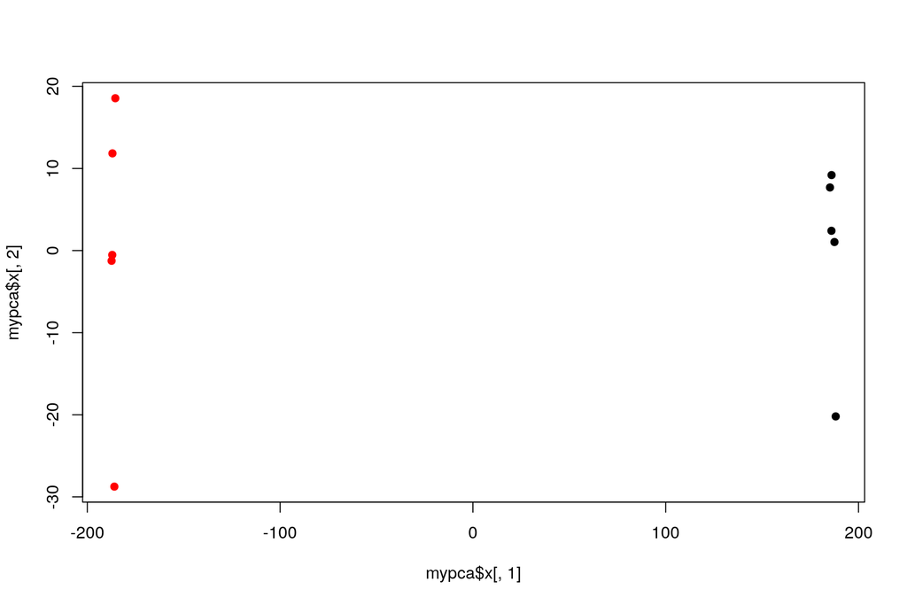

```r
plot(mypca$x[,1],mypca$x[,2],col=c(rep('red',5),rep('black',5)),pch=20,lwd=3)
```

# 4 Création des modèles statistiques pour détecter les gènes modulés

Pour rappel, le but est de comparer les niveaux d’expression de chacun des gènes entre les 5 échantillons ‘A’ et les 5 échantillons ‘B’. Nous commencçons par spécifier à R le design de notre expérience

```r
mycondition <- phenoData(expressionset)$group
mydesign <- model.matrix(~mycondition )
print(mydesign)
```

```
##    (Intercept) myconditionB
## 1            1            0
## 2            1            0
## 3            1            0
## 4            1            0
## 5            1            0
## 6            1            1
## 7            1            1
## 8            1            1
## 9            1            1
## 10           1            1
## attr(,"assign")
## [1] 0 1
## attr(,"contrasts")
## attr(,"contrasts")$mycondition
## [1] "contr.treatment"
```

Une fois que le modèle est spécifié, il est possible de créer les modèles pour chacun des gènes et de calculer les statistiques de test et les p-valeurs associées à chacun des gestes. Cela se fait en deux étapes avec les fonctions ‘lmFit’ et ‘eBayes’ du package ‘limma’.

```r
fit <- lmFit(expressionset, design=mydesign)
efit <- eBayes(fit)
```

Une fois les modèles construits, on peut aller chercher les informations qui nous intéressent et les regrouper dans une data.frame. Il s’agit de 2 éléments

1: Le coefficient d’intérêt du modèle construit pour chacun des gènes. Ce coefficient correspond à la différence moyenne entre le niveau d’expression des échantillons A et B, dans l’échelle log2. Il s’agit donc d’un ‘log2 fold-change’.

2: la p-valeur d’intérêt du modèle construit pour chacun des gènes.

```r
coefficient.affx <- fit$coefficients
head(coefficient.affx)
```

```
##           (Intercept) myconditionB
## 1007_s_at    8.202922  1.118129573
## 1053_at      8.782523 -2.715436086
## 117_at       3.801841  0.389570624
## 121_at       5.033762 -0.228221830
## 1255_g_at    2.245328  0.004115884
## 1294_at      5.307602 -1.490014595
```

```r
logfc <- coefficient.affx[,2]
pvalue <- efit$p.value
head(pvalue)
```

```
##            (Intercept) myconditionB
## 1007_s_at 5.545539e-18 2.163798e-09
## 1053_at   1.510097e-16 5.853535e-11
## 117_at    1.490467e-12 1.781719e-03
## 121_at    3.275924e-13 4.352256e-02
## 1255_g_at 3.028512e-22 2.950509e-01
## 1294_at   2.757732e-13 2.154965e-07
```

```r
pvalue <- pvalue[,2]
adj.pvalue <- p.adjust(pvalue,method='BH')

RESULT <- data.frame(as(featureData(expressionset), "data.frame"),logfc,pvalue,adj.pvalue)
RESULT <- RESULT[sort.list(RESULT$adj.pvalue),]
head(RESULT)
```

```
##              gene         ensembl      logfc       pvalue   adj.pvalue
## 206647_at     HBZ ENSG00000130656  -9.786900 2.362099e-20 6.457387e-16
## 209773_s_at  RRM2 ENSG00000171848  -9.196435 1.556850e-20 6.457387e-16
## 219466_s_at APOA2 ENSG00000158874 -10.582682 8.308908e-20 1.514298e-15
## 209138_x_at IGLC1            <NA>  -9.045762 1.619237e-19 1.519035e-15
## 229039_at    SYN2 ENSG00000157152   8.781716 1.666979e-19 1.519035e-15
## 240433_x_at CADM2 ENSG00000175161   7.180321 1.339227e-19 1.519035e-15
```

# 5 Quelques graphiques

## 5.1 Heatmap

Nous allons représenter une heatmap des 30 premiers gènes (choix arbitraire des gènes).

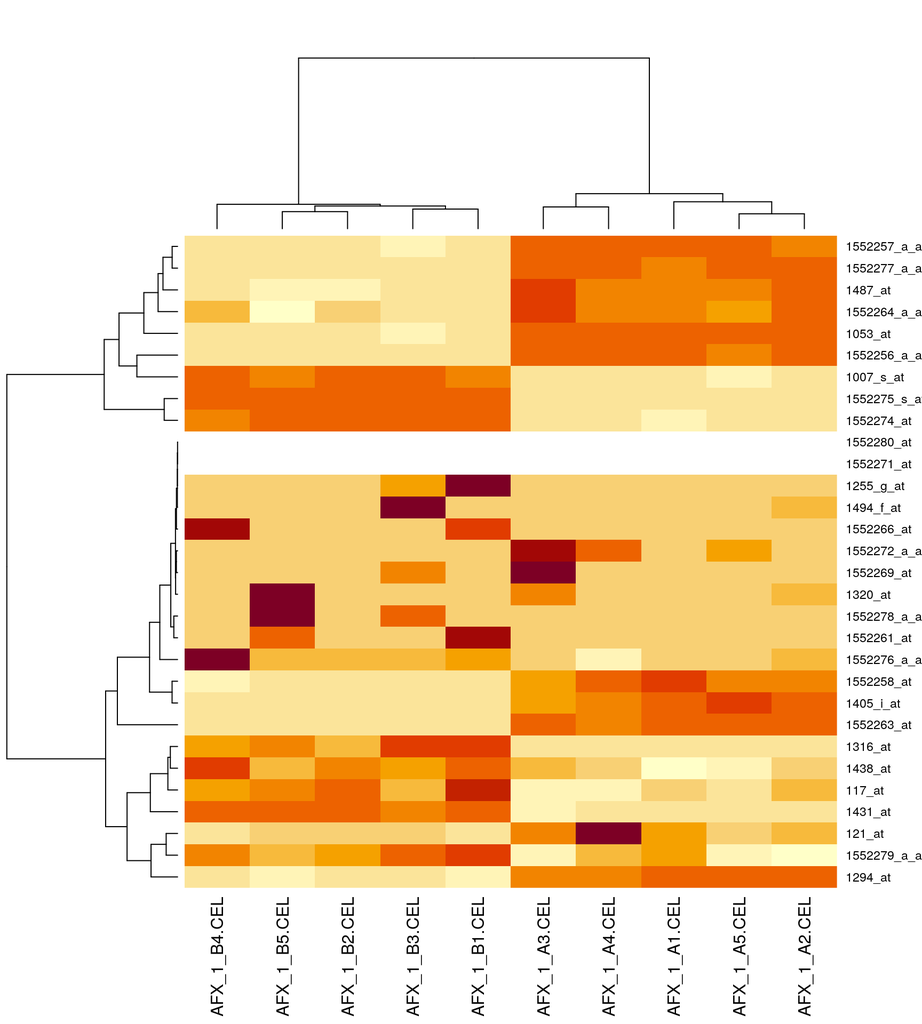

```r
heatmap(assayData(expressionset[1:30,1:10])$exprs)
```

## 5.2 Volcano

Nous allons représenter un volcano-plot.

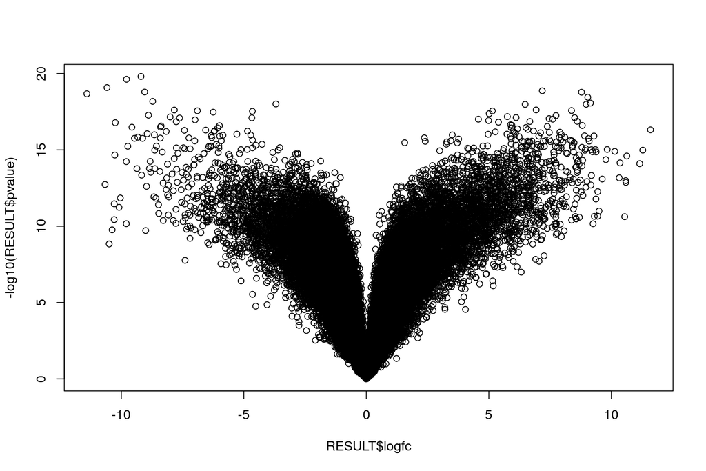

```r
plot(RESULT$logfc,-log10(RESULT$pvalue))
```